# HW 11

## Exercise 10.8

1. The goal of a posterior predictive check is to check whether a model is able to simulate data that is similar to the data used to create the model. The posterior predictive check gives insight to whether the assumptions that a Y outcome can be written as a linear function and that at any X value, Y varies normally around mu with consistent variability sigma.
2. Posterior predictive checks can be analyzed by comparing the simulated datasets to the observed dataset and looking for similarities in the spread and typical values of the simulated and observed data. If a model has a significantly different mean, range, and shape then the observed data, we know we have a bad model.

## Exercise 10.9

1. The median absolute error (MAE) tells us the typical difference between observed Y_i values and the Y_i’ means from the model. It helps us judge quality of the model.
2. The *scaled* median absolute error measures the typical number of standard deviations that observed Y_i differs from the posterior predictive Y_i’ means. It can be an improvement over MAE without a scale because it standardizes the difference which eases comparisons between models that may have different portions of the data we’ve used to train and test.
3. The within-50 statistic tells us what proportion of observed Y_i that falls within 50% of the posterior prediction interval. If this number is really low we know there’s something off about the model.

## Exercise 10.10

1. In pp_check() the darker density is the actual observed data. The light blue density represents simulated data from a model.
2. If model fits well the light blue density will have similar central tendency or tendencies and spread as the dark blue density. A good fitting model will produce a plot like this because the model has the same data structure as the observed data and produces predictions mostly within 2 or 3 standard deviations of the observed value.
3. If a model fits poorly, it may have a different shape, different central tendency, and different range (either much more less) than the observed data.

## Exercise 10.11

1. The data are the taco recipes.
2. The model is Reem. Tacos with different recipes are the input to Reem and the output is some review.
3. Cross validation could be done by splitting the data into different subsets. In this case separating the the anchovie-based recipes and non-anchovie-based recipes and testing Reem on their flavors. We could give her 90% of the tacos without the anchovies for model training and then test with the anchovies or some other type of split.
4. Cross-validation would help identify which recipe combinations are the tastiest and could help point me in the direction of the range of taco flavors to offer. I also think there could be an argument of adding more models so more people besides Reem has tasted the tacos and compare cross-validation estimates within and between the models or people in this case.

## Exercise 10.12

1. The fours steps for the k-fold cross validation algorithm are:
1. Create folds. Let k be some integer from 2 to sample size n. Split the data into k non-overlapping folds (subsets) of roughly equal size.
2. Train and test the model by training with combined data in the first k-1 folds and testing the model with k^th data fold. Measure prediction quality by MAE or other way.
3. Repeat step two k-1 times and each time leave out a different fold for testing.
4. Average the k measures from steps 2 and 3 to obtain 1 cross-validation estimate of prediction quality.
2. When you use the same data to train and test a model, the model has been optimized to capture features in the data it was built with so it produces an overly optimistic predictive accuracy.
3. My questions are how to generate how to split folds in R and in what sociological context would we use leave-one-out.

## Exercise 10.13

Load data needed for exercises.

```r
library(bayesrules)
data("coffee_ratings")
coffee_ratings <- coffee_ratings |>
  select(farm_name, total_cup_points, aroma, aftertaste)
view(coffee_ratings)
```

1. Use head to look at subsample of coffee_ratings.

```r
head(coffee_ratings, 15)
```

```
## # A tibble: 15 × 4
##    farm_name                                   total_cup_points aroma aftertaste
##    <fct>                                                  <dbl> <dbl>      <dbl>
##  1 "metad plc"                                             90.6  8.67       8.67
##  2 "metad plc"                                             89.9  8.75       8.5
##  3 "san marcos barrancas \"san cristobal cuch"             89.8  8.42       8.42
##  4 "yidnekachew dabessa coffee plantation"                 89    8.17       8.42
##  5 "metad plc"                                             88.8  8.25       8.25
##  6  <NA>                                                   88.8  8.58       8.42
##  7  <NA>                                                   88.8  8.42       8.33
##  8 "aolme"                                                 88.7  8.25       8.5
##  9 "aolme"                                                 88.4  8.67       8.58
## 10 "tulla coffee farm"                                     88.2  8.08       8.5
## 11 "fahem coffee plantation"                               88.1  8.17       8.25
## 12 "el filo"                                               87.9  8.25       8.17
## 13 "los cedros"                                            87.9  8.08       8.33
## 14 "arianna farms"                                         87.9  8.33       8.08
## 15 "aolme"                                                 87.8  8.25       8.5
```

Modeling ratings by aroma likely violates the independence assumption (conditioned on X, observed data Y_i on case i is independent of the observed data on any other case j) because given X = aroma and Y = total_cup_points a reviewer is likely comparing i cup of coffee to j cup of coffee to make determination on aroma. Similarly with aftertaste as X and Y remaining total_cup_points, a taster may evaluate aftertaste of i depending on aftertaste of j. In other words, if you’ve never tried anything other than Folgers or my favorite, Nescafe Clasico, then you won’t know if it has better or worse aroma or aftertaste than another brand.

2. Take one observation per farm and name this subsample as new_coffee for the other excercises.

```r
set.seed(84735)
new_coffee <- coffee_ratings |>
  group_by(farm_name) |> #telling R how to group data for new set
  sample_n(1) |> #telling R to take 1 sample from each group
  ungroup()
dim(new_coffee) #new_coffee has 572 observations with 4 variables
```

```
## [1] 572   4
```

## Exercise 10.14 (Coffee ratings: model it)

```r
lm(total_cup_points ~ aroma, data = new_coffee) #one estimate of parameters for a well fitting line; we see slope estimate (6.163) is positive
```

```
##
## Call:
## lm(formula = total_cup_points ~ aroma, data = new_coffee)
##
## Coefficients:
## (Intercept)        aroma
##      35.397        6.163
```

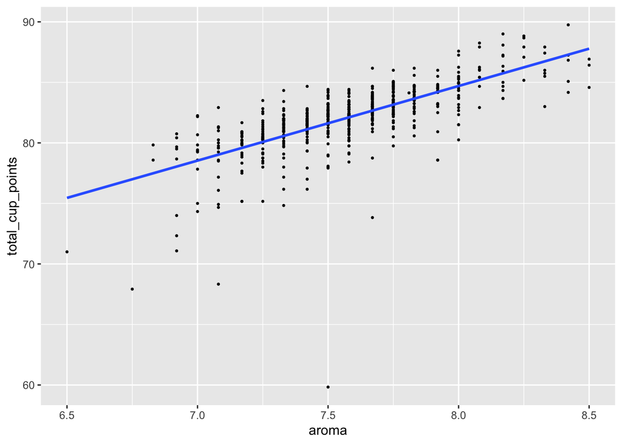

```r
ggplot(new_coffee, aes(y = total_cup_points, x = aroma)) + #plotting aroma on x axis and points on y axist
  geom_point(size = 0.5) +
  geom_smooth(method = "lm", se = FALSE)
```

The relationship between aroma and coffee rating is positive. As aroma grade increases total_cup_points increases. One model indicates that for each unit increase in aroma, cup points increase by about 6 units.

2. Could also use stan, but in b we’re asked to use stan_glm to model.

```r
coffee_model <- stan_glm(total_cup_points ~ aroma, data = new_coffee,
                       family = gaussian,
                       prior_intercept = normal(75, 10), #used range rule for sd and 75 was given
                      prior = normal(7.5, .2), #7.5 seems like a reasonable mu for B_1 based on scanning the data
                       prior_aux = exponential(0.1),#found l by 1/10
                       chains = 4, iter = 5000*2, seed = 84735)
#Store 4 chains for each parameter in 1 data frame as we might need this later.
coffee_model_df <- as.data.frame(coffee_model)
```

3. For c I’ll use tidy() to for a posterior summary of aroma.

```r
#in this step I ahve a numerical psterior summary for aroma
tidy(coffee_model, effects = c("fixed", "aux"),
     conf.int = TRUE, conf.level = 0.8)
```

```
## # A tibble: 4 × 5
##   term        estimate std.error conf.low conf.high
##   <chr>          <dbl>     <dbl>    <dbl>     <dbl>
## 1 (Intercept)    29.0     1.20      27.4      30.5
## 2 aroma           7.01    0.158      6.81      7.21
## 3 sigma           1.98    0.0590     1.90      2.05
## 4 mean_PPD       82.1     0.117     81.9      82.2
```

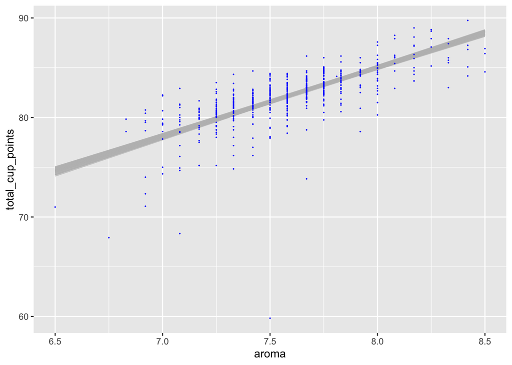

```r
# 50 simulated model lines to provide visual summary of B_1 coefficient aroma
new_coffee |>
  add_fitted_draws(coffee_model, n = 50) |>
  ggplot(aes(x = aroma, y = total_cup_points)) +
    geom_line(aes(y = .value, group = .draw), alpha = 0.7, color = "grey") +
    geom_point(data = new_coffee, size = 0.05, color = "blue")
```

```r
#plot shows 50 posterior plausible sets of B_0 and B_1 (aroma). Notice that aroma is less plausible below 7.0.
```

4. The posterior median relationship is 28.975120 + 7.010832X meaning that for every one unit increase in aroma we expect total_cup_points to increase by 7.010832.
5. I would say that yes I do based on my plots in a and c that show a positive correlation between aroma and cup score. The posterior summary of aroma shows that the 80% credible interval is above zero (6.8 - 7.2).

## Exercise 10.15

```r
#finding first set of the posterior plausible parameter sets (B_0, B_1, sigma)
first_set <- head(coffee_model_df, 1)
first_set
```

```
##   (Intercept)    aroma    sigma
## 1    27.27295 7.241494 1.909072
```

```r
#from observed data on each of the 572 observations in the new_coffee data we simulate a total_cup_points outcome from the normal data model tuned to this first parameter set

beta_0 <- first_set$`(Intercept)`#remember that beta_0 is intercept
beta_1 <- first_set$aroma #x values
sigma <- first_set$sigma

set.seed(84735)
one_simulation <- new_coffee |>
  mutate(mu = beta_0 + beta_1 * aroma, #this is linear equation with data from the first set
         simulated_points = rnorm(572, mean = mu, sd = sigma)) |> #remember 572 is sample size
  select(aroma, total_cup_points, simulated_points)
```

2. Next compare several of the data total_cup_points to the simulated points and then make density plot.

```r
head(one_simulation, 3)
```

```
## # A tibble: 3 × 3
##   aroma total_cup_points simulated_points
##   <dbl>            <dbl>            <dbl>
## 1  7.67             84               84.1
## 2  7.33             76.2             80.1
## 3  6.75             67.9             77.6
```

Density plot.

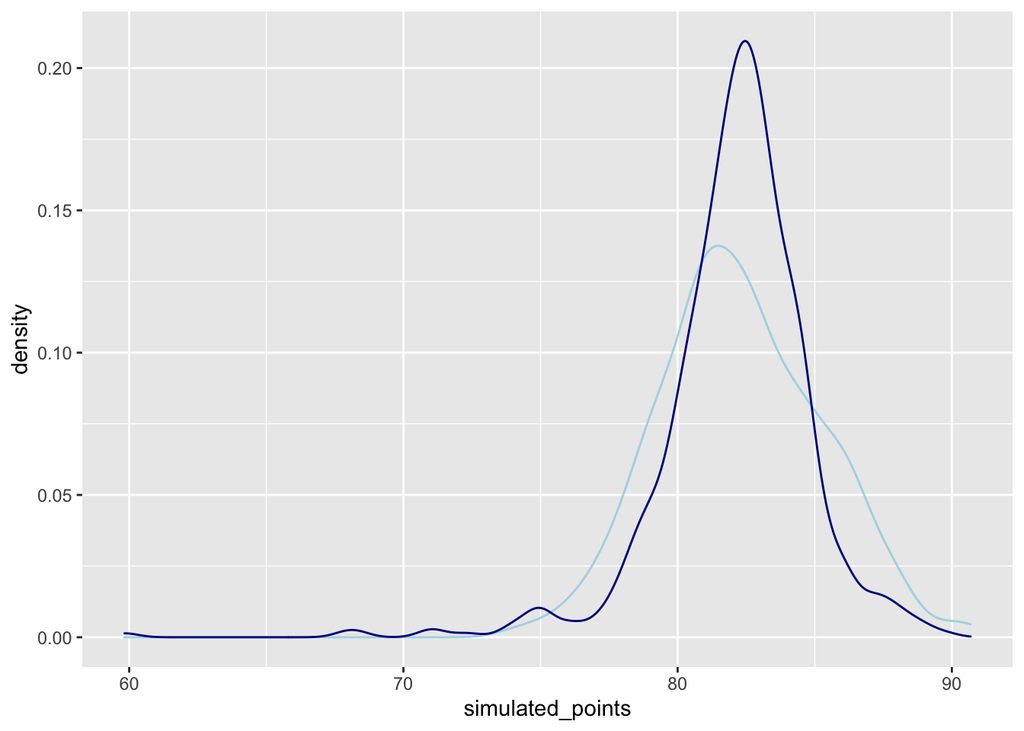

```r
ggplot(one_simulation, aes(x = simulated_points)) +
  geom_density(color = "lightblue") +
  geom_density(aes(x = total_cup_points), color = "darkblue")
```

3. Use pp_check()

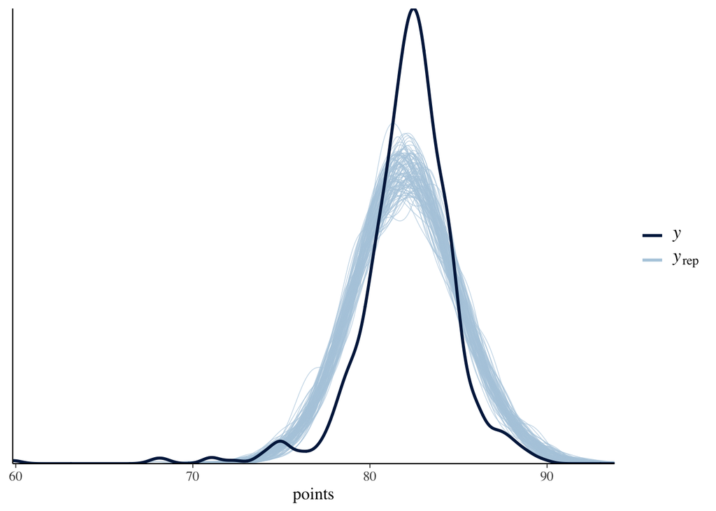

```r
#examine 100 of the 20000 simulated points
pp_check(coffee_model, nreps = 100) +
  xlab("points")
```

4. The 100 simulated lines capture the typical points (somewhere above 80) and the range. Given this, I would say that assumption 2 (that the outcome can be written as a linear function) and assumption 3 (at any X values, Y varies normally around mu with consistent variability sigma) are reasonable.